# Assignment 2

Bayesian Data Analysis and Models of Behavior

Wenjie Tu

Spring Semester 2022

$~$

### Part 1

This task is to compare the *difference-ratio-interest-finance-time* (DRIFT) model with the *intertemporal choice heuristic* (ITCH) model across five closely related conditions:

- **Condition 1:** Absolute money value, delay framing (e.g., $5 today vs. $5 plus an additional $5 in 4 weeks)
- **Condition 2:** Relative money value, delay framing (e.g., $5 today vs. $5 plus an additional 100% in 4 weeks)
- **Condition 3:** Standard MEL format (e.g., $5 today vs. $10 in 4 weeks)
- **Condition 4:** Absolute money value, speedup framing (e.g., $10 in 4 weeks vs. $10 minus $5 today)
- **Condition 5:** Relative money value, speedup framing (e.g., $10 in 4 weeks vs. $10 minus 50% today)

#### Bayesian hierarchical logistic regression

DRIFT (Difference Ratio Interest Finance Time) model:
$$\texttt{LaterOptionChosen ~ Intercept + DriftD + DriftR + DriftI +
DriftT}$$

ITCH (Intertemporal Choice Heuristics) model:
$$\texttt{LaterOptionChosen ~ Intercept + G + R + D + T}$$

Since DRIFT model and ITCH model take the same form (four regressors with intercept), we can write one single text file for these two models:

```r
if (!file.exists("./models/hierarchical_logistic_reg.txt")) {
  cat("model {
      for (k in 1:Nx) {
        b.mu[k] ~ dnorm(0, 0.0000001) # prior for coefficients (including intercept)
        b.sig[k] ~ dunif(0.1, 100)    # prior for coefficients error
      }

      for (j in 1:Nsubj) {
       for (k in 1:Nx) {
        b.s[j, k] ~ dnorm(b.mu[k], 1/b.sig[k]^2) # precision = 1/b.sig[k]^2
       }
      }

      for (i in 1:Ntotal) {
        p[i] <- ilogit( sum(b.s[subIdx[i], 1:Nx] * x[i, 1:Nx]) )
        y[i] ~ dbern(p[i])
        ly[i] <- log(p[i])
      }
    }", file="./models/hierarchical_logistic_reg.txt")
} else {
  print("The text file already existed!")
}
```

```
## [1] "The text file already existed!"
```

```r
## Load required packages
library(ggplot2)
library(GGally)
library(rjags)
library(runjags)
library(HDInterval)
library(data.table)

source("lib/deps.R")
```

```r
## NOTE: the code in this chunk is modified from HierarchicalMultipleLinearRegr_loopX.Rmd

## Set seed for reproducible results
set.seed(44566)

## Define fit.model function
## Args: data, drift
fit.model <- function(data, drift=TRUE) {

  # Generate sequential indices for participant IDs
  subIdx <- rep(1:length(table(data$Subject)), times=as.integer(table(data$Subject)))
  Nsubj <- length(unique(subIdx))
  y <- data$LaterOptionChosen

  ## Create the design matrix for DRIFT model or ITCH model
  if (drift) {
    x <- model.matrix(~ DriftD + DriftR + DriftI + DriftT, data=data)
  } else {
    x <- model.matrix(~ G + R + D + T, data=data)
  }
  Nx <- ncol(x)
  Ntotal <- nrow(x)

  ## Prepare data for JAGS
  dat.jags <- dump.format(list(
    x = x,
    y = y,
    subIdx = subIdx,
    Nsubj = Nsubj,
    Nx = Nx,
    Ntotal = Ntotal
  ))

  ## Initialize the chains
  inits1 <- dump.format(list(b.mu = runif(Nx, -2, 2), .RNG.name="base::Super-Duper", .RNG.seed=99999 ))
  inits2 <- dump.format(list(b.mu = runif(Nx, -2, 2), .RNG.name="base::Wichmann-Hill", .RNG.seed=1234))
  inits3 <- dump.format(list(b.mu = runif(Nx, -2, 2), .RNG.name="base::Mersenne-Twister", .RNG.seed=6666 ))

  ## Tell JAGS which latent variables to monitor
  monitor <- c("b.mu")

  results <- run.jags(model = "./models/hierarchical_logistic_reg.txt",
                      monitor = monitor,
                      data = dat.jags,
                      n.chains = 3,
                      inits = c(inits1, inits2, inits3),
                      burnin = 200,
                      sample = 200,
                      thin = 1)

  return(results)
}
```

Fit DRIFT model to the data:

```r
drift.results1 <- fit.model(data=load.data(1))
```

```
## Compiling rjags model...
## Calling the simulation using the rjags method...
## Adapting the model for 1000 iterations...
## Burning in the model for 200 iterations...
## Running the model for 200 iterations...
## Simulation complete
## Calculating summary statistics...
## Calculating the Gelman-Rubin statistic for 5 variables....
## Finished running the simulation
```

```r
drift.results2 <- fit.model(data=load.data(2))
```

```
## Compiling rjags model...
## Calling the simulation using the rjags method...
## Adapting the model for 1000 iterations...
## Burning in the model for 200 iterations...
## Running the model for 200 iterations...
## Simulation complete
## Calculating summary statistics...
## Calculating the Gelman-Rubin statistic for 5 variables....
## Finished running the simulation
```

```r
drift.results3 <- fit.model(data=load.data(3))
```

```
## Compiling rjags model...
## Calling the simulation using the rjags method...
## Adapting the model for 1000 iterations...
## Burning in the model for 200 iterations...
## Running the model for 200 iterations...
## Simulation complete
## Calculating summary statistics...
## Calculating the Gelman-Rubin statistic for 5 variables....
## Finished running the simulation
```

```r
drift.results4 <- fit.model(data=load.data(4))
```

```
## Compiling rjags model...
## Calling the simulation using the rjags method...
## Adapting the model for 1000 iterations...
## Burning in the model for 200 iterations...
## Running the model for 200 iterations...
## Simulation complete
## Calculating summary statistics...
## Calculating the Gelman-Rubin statistic for 5 variables....
## Finished running the simulation
```

```r
drift.results5 <- fit.model(data=load.data(5))
```

```
## Compiling rjags model...
## Calling the simulation using the rjags method...
## Adapting the model for 1000 iterations...
## Burning in the model for 200 iterations...
## Running the model for 200 iterations...
## Simulation complete
## Calculating summary statistics...
## Calculating the Gelman-Rubin statistic for 5 variables....
## Finished running the simulation
```

Fit ITCH model to the data:

```r
itch.results1 <- fit.model(data=load.data(1), drift=FALSE)
```

```
## Compiling rjags model...
## Calling the simulation using the rjags method...
## Adapting the model for 1000 iterations...
## Burning in the model for 200 iterations...
## Running the model for 200 iterations...
## Simulation complete
## Calculating summary statistics...
## Calculating the Gelman-Rubin statistic for 5 variables....
## Finished running the simulation
```

```r
itch.results2 <- fit.model(data=load.data(2), drift=FALSE)
```

```
## Compiling rjags model...
## Calling the simulation using the rjags method...
## Adapting the model for 1000 iterations...
## Burning in the model for 200 iterations...
## Running the model for 200 iterations...
## Simulation complete
## Calculating summary statistics...
## Calculating the Gelman-Rubin statistic for 5 variables....
## Finished running the simulation
```

```r
itch.results3 <- fit.model(data=load.data(3), drift=FALSE)
```

```
## Compiling rjags model...
## Calling the simulation using the rjags method...
## Adapting the model for 1000 iterations...
## Burning in the model for 200 iterations...
## Running the model for 200 iterations...
## Simulation complete
## Calculating summary statistics...
## Calculating the Gelman-Rubin statistic for 5 variables....
## Finished running the simulation
```

```r
itch.results4 <- fit.model(data=load.data(4), drift=FALSE)
```

```
## Compiling rjags model...
## Calling the simulation using the rjags method...
## Adapting the model for 1000 iterations...
## Burning in the model for 200 iterations...
## Running the model for 200 iterations...
## Simulation complete
## Calculating summary statistics...
## Calculating the Gelman-Rubin statistic for 5 variables....
## Finished running the simulation
```

```r
itch.results5 <- fit.model(data=load.data(5), drift=FALSE)
```

```
## Compiling rjags model...
## Calling the simulation using the rjags method...
## Adapting the model for 1000 iterations...
## Burning in the model for 200 iterations...
## Running the model for 200 iterations...
## Simulation complete
## Calculating summary statistics...
## Calculating the Gelman-Rubin statistic for 5 variables....
## Finished running the simulation
```

#### Correlation and density plots

Correlation and density plots for DRIFT model:

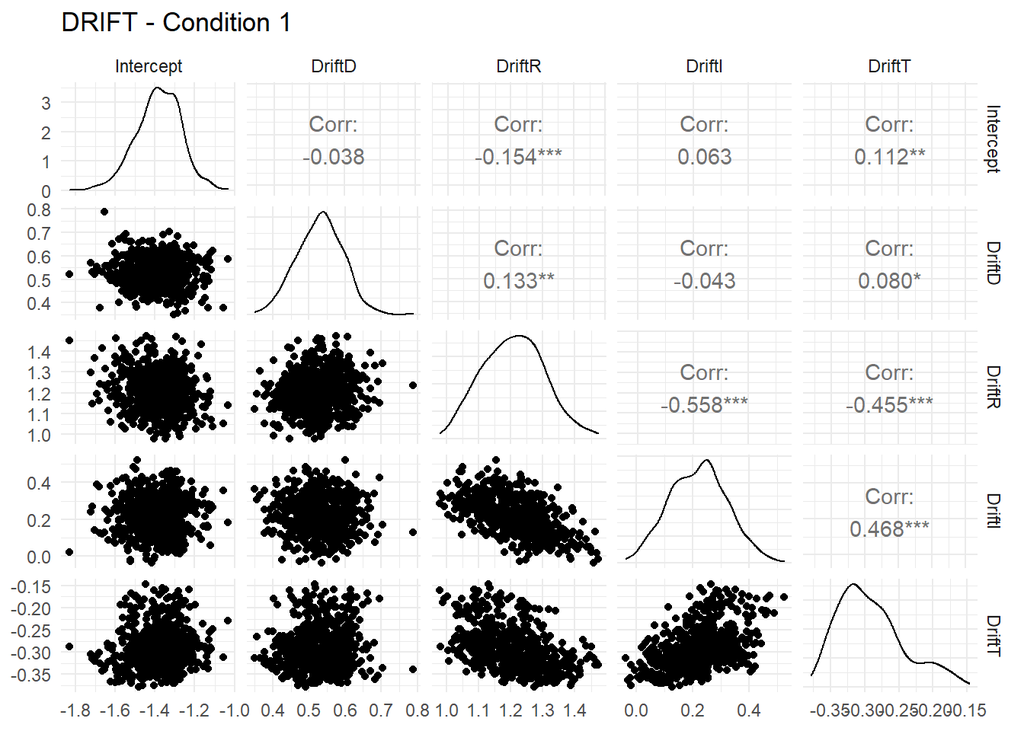

```r
d.drift1 <- data.frame(rbind(
  drift.results1[["mcmc"]][[1]],
  drift.results1[["mcmc"]][[2]],
  drift.results1[["mcmc"]][[3]]
))
names(d.drift1) <- c("Intercept", "DriftD", "DriftR", "DriftI", "DriftT")
ggpairs(d.drift1, title="DRIFT - Condition 1") + theme_minimal()
```

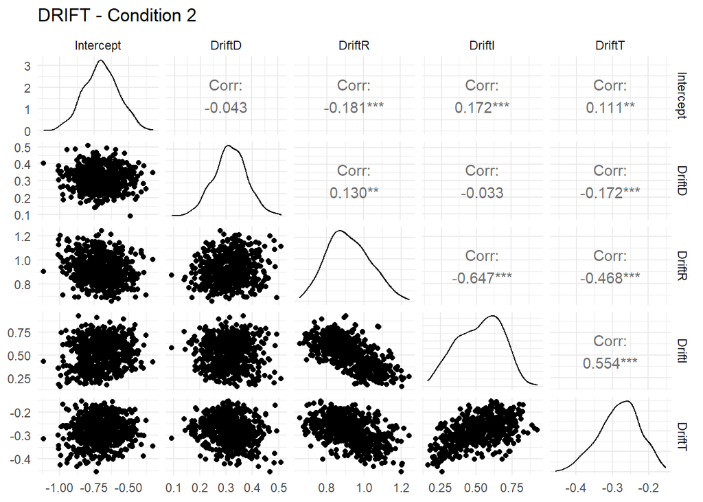

```r
d.drift2 <- data.frame(rbind(
  drift.results2[["mcmc"]][[1]],
  drift.results2[["mcmc"]][[2]],
  drift.results2[["mcmc"]][[3]]
))
names(d.drift2) <- c("Intercept", "DriftD", "DriftR", "DriftI", "DriftT")
ggpairs(d.drift2, title="DRIFT - Condition 2") + theme_minimal()
```

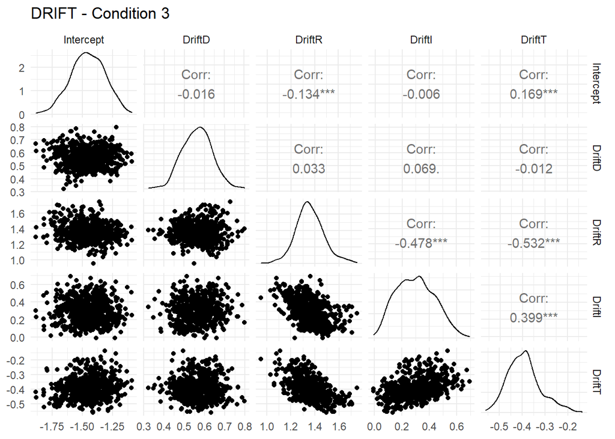

```r
d.drift3 <- data.frame(rbind(
  drift.results3[["mcmc"]][[1]],
  drift.results3[["mcmc"]][[2]],
  drift.results3[["mcmc"]][[3]]
))
names(d.drift3) <- c("Intercept", "DriftD", "DriftR", "DriftI", "DriftT")
ggpairs(d.drift3, title="DRIFT - Condition 3") + theme_minimal()
```

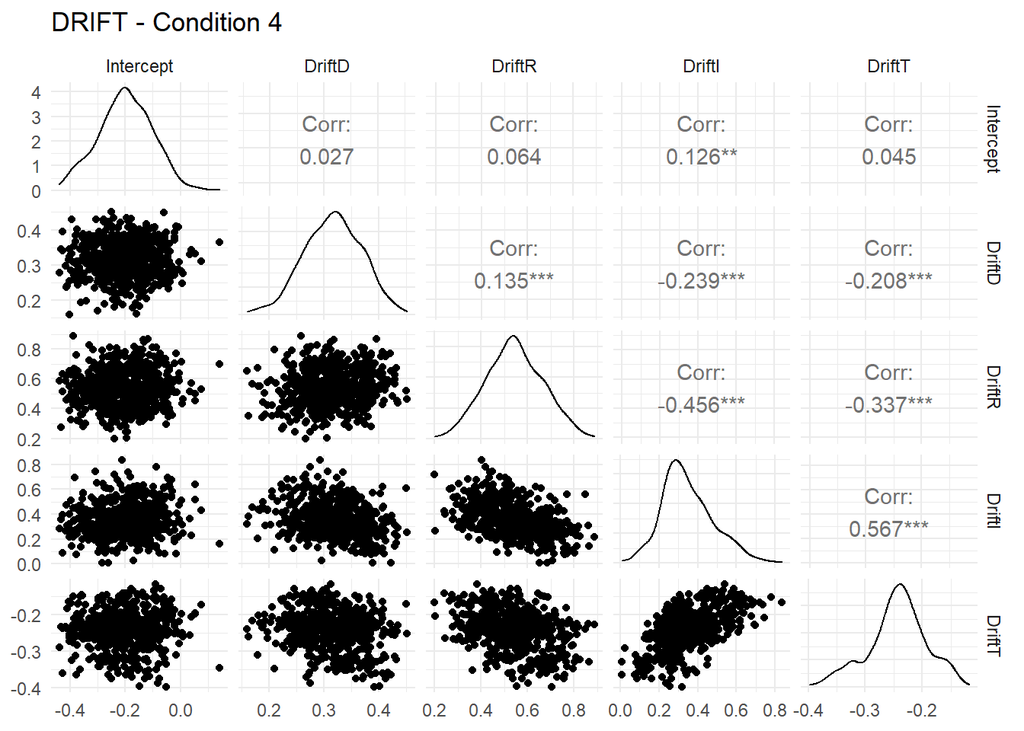

```r
d.drift4 <- data.frame(rbind(
  drift.results4[["mcmc"]][[1]],
  drift.results4[["mcmc"]][[2]],
  drift.results4[["mcmc"]][[3]]
))
names(d.drift4) <- c("Intercept", "DriftD", "DriftR", "DriftI", "DriftT")
ggpairs(d.drift4, title="DRIFT - Condition 4") + theme_minimal()
```

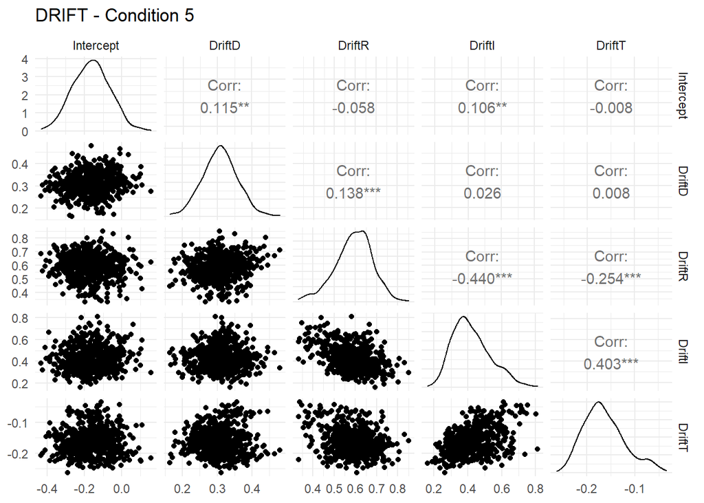

```r
d.drift5 <- data.frame(rbind(
  drift.results5[["mcmc"]][[1]],
  drift.results5[["mcmc"]][[2]],
  drift.results5[["mcmc"]][[3]]
))
names(d.drift5) <- c("Intercept", "DriftD", "DriftR", "DriftI", "DriftT")
ggpairs(d.drift5, title="DRIFT - Condition 5") + theme_minimal()
```

Correlation and density plots for ITCH model:

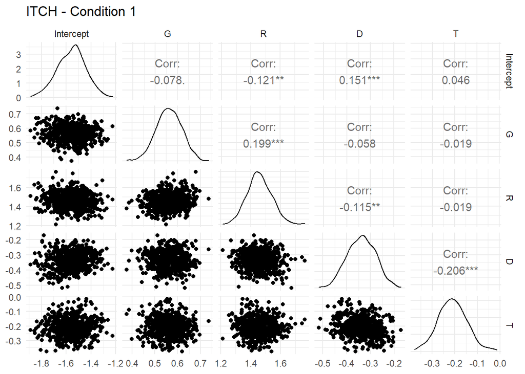

```r
d.itch1 <- data.frame(rbind(
  itch.results1[["mcmc"]][[1]],
  itch.results1[["mcmc"]][[2]],
  itch.results1[["mcmc"]][[3]]
))
names(d.itch1) <- c("Intercept", "G", "R", "D", "T")
ggpairs(d.itch1, title="ITCH - Condition 1") + theme_minimal()
```

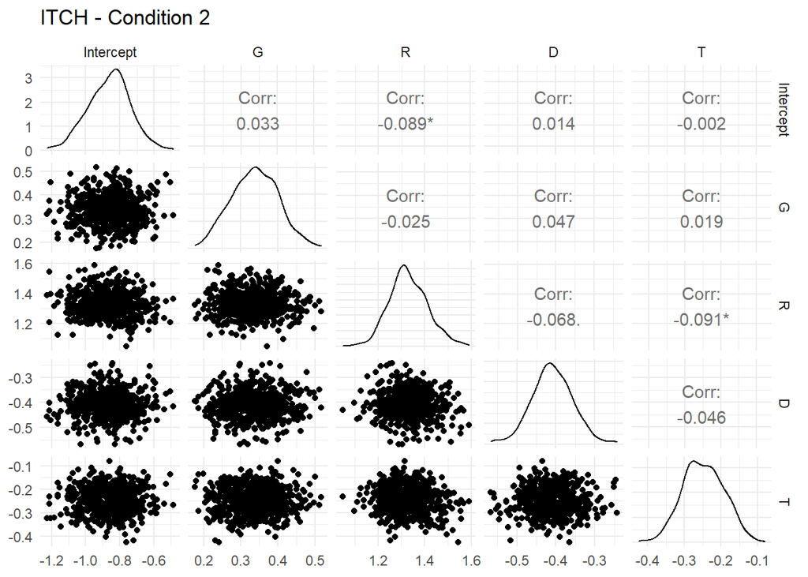

```r
d.itch2 <- data.frame(rbind(
  itch.results2[["mcmc"]][[1]],
  itch.results2[["mcmc"]][[2]],
  itch.results2[["mcmc"]][[3]]
))
names(d.itch2) <- c("Intercept", "G", "R", "D", "T")
ggpairs(d.itch2, title="ITCH - Condition 2") + theme_minimal()
```

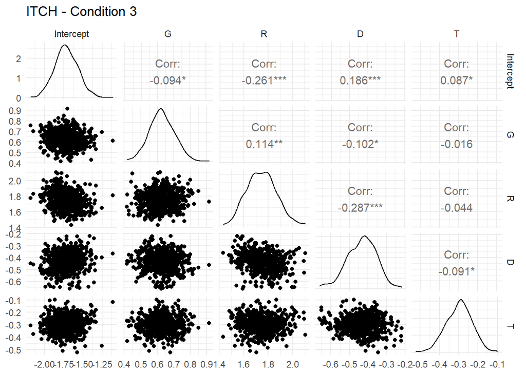

```r
d.itch3 <- data.frame(rbind(
  itch.results3[["mcmc"]][[1]],
  itch.results3[["mcmc"]][[2]],
  itch.results3[["mcmc"]][[3]]
))
names(d.itch3) <- c("Intercept", "G", "R", "D", "T")
ggpairs(d.itch3, title="ITCH - Condition 3") + theme_minimal()
```

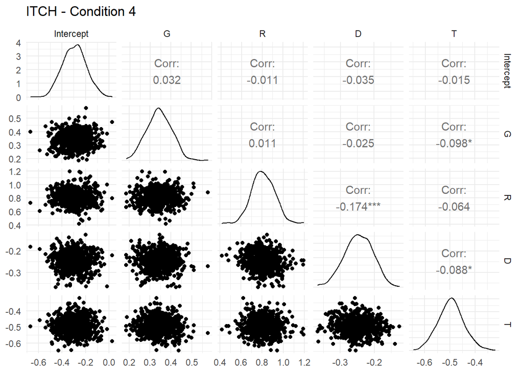

```r
d.itch4 <- data.frame(rbind(
  itch.results4[["mcmc"]][[1]],
  itch.results4[["mcmc"]][[2]],
  itch.results4[["mcmc"]][[3]]
))
names(d.itch4) <- c("Intercept", "G", "R", "D", "T")
ggpairs(d.itch4, title="ITCH - Condition 4") + theme_minimal()
```

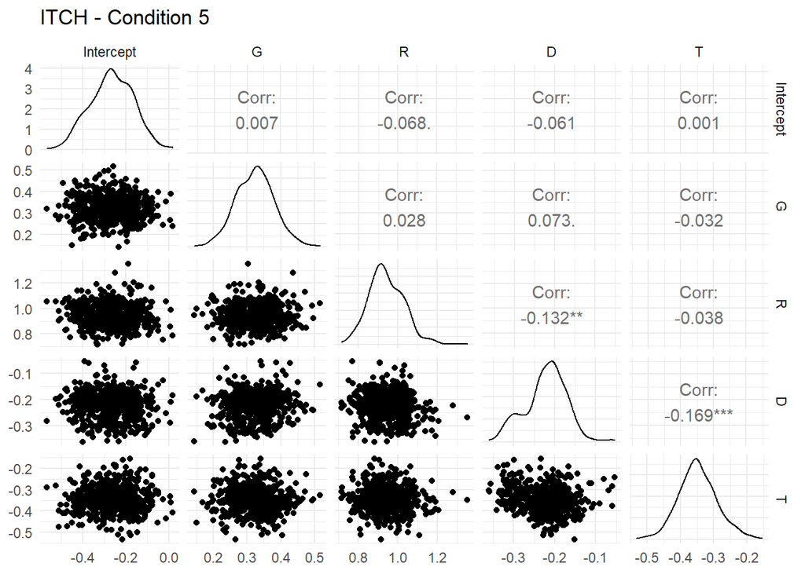

```r
d.itch5 <- data.frame(rbind(
  itch.results5[["mcmc"]][[1]],
  itch.results5[["mcmc"]][[2]],
  itch.results5[["mcmc"]][[3]]
))
names(d.itch5) <- c("Intercept", "G", "R", "D", "T")
ggpairs(d.itch5, title="ITCH - Condition 5") + theme_minimal()
```

#### Summary tables

Summary tables for DRIFT model:

```r
knitr::kable(summary(drift.results1), caption="DRIFT - Condition 1", digits=6, align="c")
```

DRIFT - Condition 1

|  | Lower95 | Median | Upper95 | Mean | SD | Mode | MCerr | MC%ofSD | SSeff | AC.10 | psrf |
| --- | --- | --- | --- | --- | --- | --- | --- | --- | --- | --- | --- |
| b.mu[1] | -1.636593 | -1.377632 | -1.183035 | -1.382018 | 0.112797 | NA | 0.005796 | 5.1 | 379 | -0.015890 | 1.025937 |
| b.mu[2] | 0.399932 | 0.532051 | 0.641548 | 0.529785 | 0.063478 | NA | 0.005774 | 9.1 | 121 | 0.052396 | 1.007752 |
| b.mu[3] | 1.030806 | 1.209411 | 1.393789 | 1.208486 | 0.096554 | NA | 0.010200 | 10.6 | 90 | 0.174515 | 1.336183 |
| b.mu[4] | 0.033193 | 0.224608 | 0.416671 | 0.219113 | 0.101084 | NA | 0.013895 | 13.7 | 53 | 0.195900 | 1.414711 |
| b.mu[5] | -0.369665 | -0.298216 | -0.187786 | -0.290765 | 0.048706 | NA | 0.006802 | 14.0 | 51 | 0.293455 | 1.769859 |

```r
knitr::kable(summary(drift.results2), caption="DRIFT - Condition 2", digits=6, align="c")
```

DRIFT - Condition 2

|  | Lower95 | Median | Upper95 | Mean | SD | Mode | MCerr | MC%ofSD | SSeff | AC.10 | psrf |
| --- | --- | --- | --- | --- | --- | --- | --- | --- | --- | --- | --- |
| b.mu[1] | -0.950593 | -0.699840 | -0.467901 | -0.699846 | 0.124805 | NA | 0.006652 | 5.3 | 352 | 0.042549 | 1.004802 |
| b.mu[2] | 0.178832 | 0.314718 | 0.428484 | 0.315204 | 0.063611 | NA | 0.005259 | 8.3 | 146 | -0.021970 | 1.010574 |
| b.mu[3] | 0.720773 | 0.904814 | 1.155503 | 0.917357 | 0.113812 | NA | 0.019111 | 16.8 | 35 | 0.376041 | 1.078859 |
| b.mu[4] | 0.215824 | 0.542949 | 0.777168 | 0.524793 | 0.155821 | NA | 0.029022 | 18.6 | 29 | 0.439609 | 1.217724 |
| b.mu[5] | -0.392961 | -0.277144 | -0.180649 | -0.280798 | 0.056050 | NA | 0.010760 | 19.2 | 27 | 0.404855 | 1.090282 |

```r
knitr::kable(summary(drift.results3), caption="DRIFT - Condition 3", digits=6, align="c")
```

DRIFT - Condition 3

|  | Lower95 | Median | Upper95 | Mean | SD | Mode | MCerr | MC%ofSD | SSeff | AC.10 | psrf |
| --- | --- | --- | --- | --- | --- | --- | --- | --- | --- | --- | --- |
| b.mu[1] | -1.720763 | -1.456488 | -1.188302 | -1.456769 | 0.141680 | NA | 0.007329 | 5.2 | 374 | 0.022191 | 1.033063 |
| b.mu[2] | 0.426025 | 0.565642 | 0.696141 | 0.563995 | 0.072608 | NA | 0.006202 | 8.5 | 137 | 0.062242 | 1.060793 |
| b.mu[3] | 1.138975 | 1.351464 | 1.624721 | 1.359224 | 0.116675 | NA | 0.013350 | 11.4 | 76 | 0.303322 | 1.239244 |
| b.mu[4] | 0.042540 | 0.299378 | 0.537733 | 0.299391 | 0.137632 | NA | 0.026321 | 19.1 | 27 | 0.397483 | 1.138064 |
| b.mu[5] | -0.525788 | -0.395625 | -0.235063 | -0.392258 | 0.072332 | NA | 0.012717 | 17.6 | 32 | 0.358760 | 1.595172 |

```r
knitr::kable(summary(drift.results4), caption="DRIFT - Condition 4", digits=6, align="c")
```

DRIFT - Condition 4

|  | Lower95 | Median | Upper95 | Mean | SD | Mode | MCerr | MC%ofSD | SSeff | AC.10 | psrf |
| --- | --- | --- | --- | --- | --- | --- | --- | --- | --- | --- | --- |
| b.mu[1] | -0.404490 | -0.198147 | -0.037487 | -0.199283 | 0.097049 | NA | 0.004538 | 4.7 | 457 | 0.020073 | 1.021303 |
| b.mu[2] | 0.221947 | 0.317162 | 0.423084 | 0.315899 | 0.052352 | NA | 0.004094 | 7.8 | 163 | 0.044272 | 1.047999 |
| b.mu[3] | 0.294842 | 0.541584 | 0.771073 | 0.543879 | 0.123108 | NA | 0.009414 | 7.6 | 171 | 0.147622 | 1.164405 |
| b.mu[4] | 0.107633 | 0.328227 | 0.624083 | 0.349223 | 0.132613 | NA | 0.019579 | 14.8 | 46 | 0.287104 | 1.655016 |
| b.mu[5] | -0.352273 | -0.239973 | -0.146833 | -0.243586 | 0.051752 | NA | 0.010046 | 19.4 | 27 | 0.453276 | 1.581619 |

```r
knitr::kable(summary(drift.results5), caption="DRIFT - Condition 5", digits=6, align="c")
```

DRIFT - Condition 5

|  | Lower95 | Median | Upper95 | Mean | SD | Mode | MCerr | MC%ofSD | SSeff | AC.10 | psrf |
| --- | --- | --- | --- | --- | --- | --- | --- | --- | --- | --- | --- |
| b.mu[1] | -0.356726 | -0.163334 | 0.012641 | -0.162882 | 0.098412 | NA | 0.005359 | 5.4 | 337 | -0.002105 | 1.003715 |
| b.mu[2] | 0.201719 | 0.307261 | 0.396299 | 0.307784 | 0.050223 | NA | 0.004693 | 9.3 | 115 | -0.041776 | 1.024863 |
| b.mu[3] | 0.411425 | 0.597291 | 0.756559 | 0.591871 | 0.087330 | NA | 0.007988 | 9.1 | 120 | 0.141480 | 1.082136 |
| b.mu[4] | 0.244396 | 0.403551 | 0.660856 | 0.422036 | 0.112283 | NA | 0.018203 | 16.2 | 38 | 0.348134 | 1.301754 |
| b.mu[5] | -0.232169 | -0.169440 | -0.065125 | -0.163698 | 0.043088 | NA | 0.007852 | 18.2 | 30 | 0.479524 | 1.447924 |

Summary tables for ITCH model:

```r
knitr::kable(summary(itch.results1), caption="ITCH - Condition 1", digits=6, align="c")
```

ITCH - Condition 1

|  | Lower95 | Median | Upper95 | Mean | SD | Mode | MCerr | MC%ofSD | SSeff | AC.10 | psrf |
| --- | --- | --- | --- | --- | --- | --- | --- | --- | --- | --- | --- |
| b.mu[1] | -1.791651 | -1.550767 | -1.350469 | -1.556951 | 0.112468 | NA | 0.005874 | 5.2 | 367 | -0.007800 | 1.027885 |
| b.mu[2] | 0.457809 | 0.561834 | 0.670922 | 0.561847 | 0.055234 | NA | 0.004119 | 7.5 | 180 | 0.065913 | 1.047426 |
| b.mu[3] | 1.300662 | 1.456748 | 1.617672 | 1.458800 | 0.081734 | NA | 0.006199 | 7.6 | 174 | 0.044591 | 1.041853 |
| b.mu[4] | -0.455587 | -0.336840 | -0.238772 | -0.338170 | 0.057859 | NA | 0.010512 | 18.2 | 30 | 0.473703 | 1.102447 |
| b.mu[5] | -0.350458 | -0.210706 | -0.099353 | -0.208951 | 0.063501 | NA | 0.005869 | 9.2 | 117 | 0.061433 | 1.076573 |

```r
knitr::kable(summary(itch.results2), caption="ITCH - Condition 2", digits=6, align="c")
```

ITCH - Condition 2

|  | Lower95 | Median | Upper95 | Mean | SD | Mode | MCerr | MC%ofSD | SSeff | AC.10 | psrf |
| --- | --- | --- | --- | --- | --- | --- | --- | --- | --- | --- | --- |
| b.mu[1] | -1.106776 | -0.853809 | -0.631596 | -0.862944 | 0.123603 | NA | 0.006265 | 5.1 | 389 | -0.032517 | 1.017537 |
| b.mu[2] | 0.214021 | 0.338335 | 0.455711 | 0.337852 | 0.062936 | NA | 0.004510 | 7.2 | 195 | 0.046976 | 1.005128 |
| b.mu[3] | 1.178582 | 1.323068 | 1.492427 | 1.329985 | 0.081805 | NA | 0.006733 | 8.2 | 148 | 0.012206 | 1.018946 |
| b.mu[4] | -0.520151 | -0.409360 | -0.311140 | -0.409055 | 0.053257 | NA | 0.006392 | 12.0 | 69 | 0.018949 | 1.022001 |
| b.mu[5] | -0.363864 | -0.250364 | -0.152541 | -0.248206 | 0.056173 | NA | 0.006702 | 11.9 | 70 | 0.148015 | 1.024347 |

```r
knitr::kable(summary(itch.results3), caption="ITCH - Condition 3", digits=6, align="c")
```

ITCH - Condition 3

|  | Lower95 | Median | Upper95 | Mean | SD | Mode | MCerr | MC%ofSD | SSeff | AC.10 | psrf |
| --- | --- | --- | --- | --- | --- | --- | --- | --- | --- | --- | --- |
| b.mu[1] | -2.059601 | -1.720472 | -1.468833 | -1.717223 | 0.150713 | NA | 0.007483 | 5.0 | 406 | -0.022508 | 1.074645 |
| b.mu[2] | 0.481260 | 0.625383 | 0.770658 | 0.627195 | 0.075605 | NA | 0.006770 | 9.0 | 125 | -0.024471 | 1.018285 |
| b.mu[3] | 1.527679 | 1.744970 | 1.961111 | 1.745503 | 0.115484 | NA | 0.012153 | 10.5 | 90 | 0.186942 | 1.206521 |
| b.mu[4] | -0.611019 | -0.427713 | -0.299795 | -0.433242 | 0.078757 | NA | 0.012007 | 15.2 | 43 | 0.187067 | 1.187880 |
| b.mu[5] | -0.428736 | -0.293778 | -0.176413 | -0.297846 | 0.067304 | NA | 0.006810 | 10.1 | 98 | 0.097040 | 1.034603 |

```r
knitr::kable(summary(itch.results4), caption="ITCH - Condition 4", digits=6, align="c")
```

ITCH - Condition 4

|  | Lower95 | Median | Upper95 | Mean | SD | Mode | MCerr | MC%ofSD | SSeff | AC.10 | psrf |
| --- | --- | --- | --- | --- | --- | --- | --- | --- | --- | --- | --- |
| b.mu[1] | -0.486504 | -0.295150 | -0.109159 | -0.295009 | 0.099888 | NA | 0.004518 | 4.5 | 489 | 0.031861 | 1.007558 |
| b.mu[2] | 0.230603 | 0.341811 | 0.449785 | 0.342888 | 0.059169 | NA | 0.005307 | 9.0 | 124 | -0.040380 | 1.055109 |
| b.mu[3] | 0.606805 | 0.807247 | 1.017244 | 0.810303 | 0.109633 | NA | 0.005236 | 4.8 | 438 | 0.011173 | 1.005517 |
| b.mu[4] | -0.329863 | -0.244873 | -0.172389 | -0.246384 | 0.041706 | NA | 0.007598 | 18.2 | 30 | 0.294607 | 1.062015 |
| b.mu[5] | -0.595870 | -0.495749 | -0.393444 | -0.495823 | 0.051140 | NA | 0.004950 | 9.7 | 107 | 0.057254 | 1.031454 |

```r
knitr::kable(summary(itch.results5), caption="ITCH - Condition 5", digits=6, align="c")
```

ITCH - Condition 5

|  | Lower95 | Median | Upper95 | Mean | SD | Mode | MCerr | MC%ofSD | SSeff | AC.10 | psrf |
| --- | --- | --- | --- | --- | --- | --- | --- | --- | --- | --- | --- |
| b.mu[1] | -0.442221 | -0.264488 | -0.076111 | -0.265833 | 0.099367 | NA | 0.004648 | 4.7 | 457 | -0.055710 | 1.001095 |
| b.mu[2] | 0.200476 | 0.325253 | 0.427621 | 0.323425 | 0.057469 | NA | 0.005846 | 10.2 | 97 | 0.047524 | 1.007655 |
| b.mu[3] | 0.753481 | 0.933183 | 1.088349 | 0.942585 | 0.089447 | NA | 0.006206 | 6.9 | 208 | -0.003912 | 1.015816 |
| b.mu[4] | -0.329916 | -0.215871 | -0.142541 | -0.221434 | 0.051024 | NA | 0.012715 | 24.9 | 16 | 0.594084 | 1.175385 |
| b.mu[5] | -0.456386 | -0.349885 | -0.225366 | -0.347581 | 0.058649 | NA | 0.004569 | 7.8 | 165 | 0.037933 | 1.015399 |

$~$

### Part 2

This task is to compare the percentage of Larger-Later choices by framing condition using a **robust** Bayesian ANOVA-like model.

#### Bayesian one-way ANOVA

Assumption: the variance is homogeneous across different conditions

Conditions:

- Condition 1: Absolute Gains
- Condition 2: Relative Gains
- Condition 3: Standard MEL
- Condition 4: Absolute Losses
- Condition 5: Relative Losses

Graphical representation:

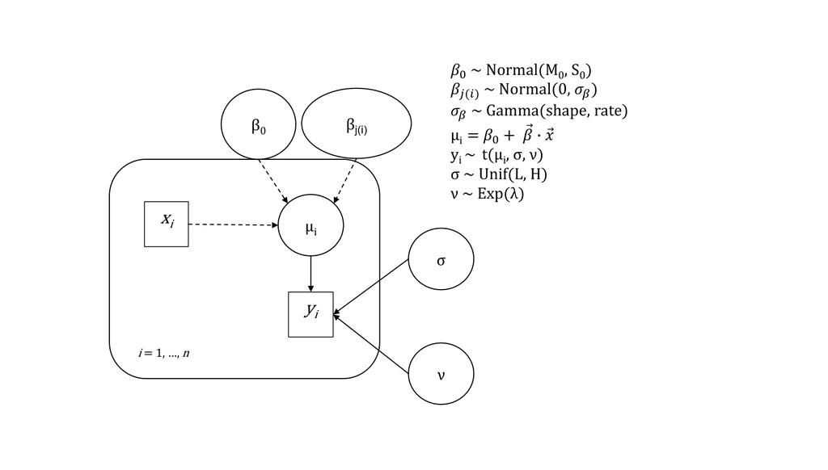

- The robust Bayesian ANOVA model uses a $t$-distribution as it has heavier tails and is more robust to outliers than the normal distribution.
- We can control the kurtosis of the distribution by assuming a prior for the degrees of freedom parameter $\nu$. We assume that the degrees of freedom parameter $\nu$ in the $t$-distribution follows an exponential distribution with the rate parameter $\lambda=\frac{1}{30}$ (heavy-tailed).

```r
if (!file.exists("./models/robust_1way_ANOVA_homo_var.txt")) {
  cat("model {
      ySigma ~ dunif( ySD/100 , ySD*10 )
      a0 ~ dnorm( yMean , 1/(ySD*5)^2 )
      aSigma ~ dgamma( agammaShRa[1] , agammaShRa[2] )

      for ( j in 1:NxLvl ) {
          a[j] ~ dnorm( 0.0 , 1/aSigma^2 )
      }

      nu ~ dexp(1/30.0) # degrees of freedom for t-distribution
      for ( i in 1:Ntotal ) {
          y[i] ~ dt( a0 + a[x[i]] , 1/ySigma^2 , nu ) # robust estimation
      }

      # Convert a0, a[] to sum-to-zero b0,b[] :
      for ( j in 1:NxLvl ) {
          m[j] <- a0 + a[j] # cell means
      }

      b0 <- mean( m[1:NxLvl] )
      for ( j in 1:NxLvl ) {
          b[j] <- m[j] - b0
      }
  }", file="./models/robust_1way_ANOVA_homo_var.txt")
} else {
  print("The text file already existed!")
}
```

```
## [1] "The text file already existed!"
```

```r
## NOTE: code in this chunk is modified from the lecture script OneFactorAnovaHomVar.R
source("moustache_plot.r")
gammaShRaFromModeSD <- function(mode, sd) {
  if (mode <= 0) stop("mode must be > 0")
  if (sd <= 0) stop("sd must be > 0")
  rate = (mode + sqrt( mode^2 + 4 * sd^2 )) / (2 * sd^2)
  shape = 1 + mode * rate
  return(c(shape, rate))
}

DT <- data.table(load.data(0))

DT <- DT[, list(LaterOptionChosenRate = mean(LaterOptionChosen)), by=c("Subject", "Condition")]

# Using code provided in lecture:
# Convert data file columns to generic x,y variable names for model:
y <- as.numeric(DT$LaterOptionChosenRate)
x <- as.numeric(as.factor(DT$Condition))
xlevels <- levels(as.factor(DT$Condition))
Ntotal <- length(y)
NxLvl <- length(unique(x))
# Compute scale properties of data, for passing into prior to make the prior
# vague on the scale of the data.
# For prior on baseline, etc.:
yMean <- mean(y)
ySD <- sd(y)
# For hyper-prior on deflections:
agammaShRa <- gammaShRaFromModeSD(mode=sd(y)/2, sd=2*sd(y))
# Specify the data in a list for sending to JAGS:
dataList <- list(
  y = y,
  x = x,
  Ntotal = Ntotal,
  NxLvl = NxLvl,
  # data properties for scaling the prior:
  yMean = yMean,
  ySD = ySD,
  agammaShRa = agammaShRa
)

#------------------------------------------------------------------------------
# INTIALIZE THE CHAINS.

DT.group <- DT[, list(Mean=mean(LaterOptionChosenRate), SD=sd(LaterOptionChosenRate)), by="Condition"]

initsList <- list(
  a0 = yMean ,
  a = DT.group$Mean - yMean ,
  ySigma = mean(DT.group$SD)
  # Let JAGS do other parameters automatically...
)

inits1 <- dump.format(c(initsList, list(.RNG.name="base::Super-Duper", .RNG.seed=99999)))
inits2 <- dump.format(c(initsList, list(.RNG.name="base::Wichmann-Hill", .RNG.seed=1234)))
inits3 <- dump.format(c(initsList, list(.RNG.name="base::Mersenne-Twister", .RNG.seed=6666)))

#------------------------------------------------------------------------------
# RUN THE CHAINS
monitor <- c("b0", "b", "m", "aSigma", "ySigma")
adaptSteps <- 500
burnInSteps <- 5000
nChains <- 3
results <- run.jags(model = "./models/robust_1way_ANOVA_homo_var.txt",
                    monitor = monitor,
                    data = dataList,
                    inits = c(inits1, inits2, inits3),
                    n.chains = nChains,
                    adapt = adaptSteps,
                    burnin = burnInSteps,
                    sample = 5000,
                    thin = 1,
                    summarise = FALSE,
                    plots = FALSE)
```

```
## Compiling rjags model...
## Calling the simulation using the rjags method...
## Adapting the model for 500 iterations...
## Burning in the model for 5000 iterations...
## Running the model for 5000 iterations...
## Simulation complete
## Finished running the simulation
```

```r
## Print the summary results in a table
knitr::kable(summary(results), digits=6, align="c", caption="Summary results for robust Bayesian one-way ANOVA")
```

```
## Calculating summary statistics...
## Calculating the Gelman-Rubin statistic for 13 variables....
## Note: Unable to calculate the multivariate psrf
```

Summary results for robust Bayesian one-way ANOVA

|  | Lower95 | Median | Upper95 | Mean | SD | Mode | MCerr | MC%ofSD | SSeff | AC.10 | psrf |
| --- | --- | --- | --- | --- | --- | --- | --- | --- | --- | --- | --- |
| b0 | 0.351683 | 0.366212 | 0.381260 | 0.366267 | 0.007549 | NA | 0.000071 | 0.9 | 11325 | 0.002611 | 1.000117 |
| b[1] | -0.106754 | -0.078393 | -0.050124 | -0.078427 | 0.014544 | NA | 0.000152 | 1.0 | 9199 | 0.004368 | 0.999974 |
| b[2] | -0.022411 | 0.005336 | 0.032753 | 0.005354 | 0.014065 | NA | 0.000146 | 1.0 | 9258 | 0.005456 | 1.000288 |
| b[3] | -0.105986 | -0.076154 | -0.046092 | -0.076135 | 0.015344 | NA | 0.000163 | 1.1 | 8867 | 0.002062 | 0.999992 |
| b[4] | 0.047236 | 0.074699 | 0.102773 | 0.074752 | 0.014416 | NA | 0.000151 | 1.0 | 9118 | -0.001722 | 1.000343 |
| b[5] | 0.045171 | 0.074304 | 0.102991 | 0.074456 | 0.014756 | NA | 0.000159 | 1.1 | 8655 | 0.021445 | 1.000068 |
| m[1] | 0.256337 | 0.287908 | 0.319803 | 0.287840 | 0.016263 | NA | 0.000168 | 1.0 | 9387 | 0.000518 | 0.999993 |
| m[2] | 0.339948 | 0.371599 | 0.402080 | 0.371620 | 0.015741 | NA | 0.000159 | 1.0 | 9829 | 0.003413 | 1.000404 |
| m[3] | 0.254376 | 0.290004 | 0.323020 | 0.290131 | 0.017660 | NA | 0.000181 | 1.0 | 9481 | 0.008620 | 1.000010 |
| m[4] | 0.410112 | 0.441129 | 0.472082 | 0.441019 | 0.016012 | NA | 0.000164 | 1.0 | 9535 | -0.004006 | 1.000082 |
| m[5] | 0.407473 | 0.440728 | 0.472289 | 0.440723 | 0.016577 | NA | 0.000173 | 1.0 | 9212 | 0.018482 | 0.999960 |
| aSigma | 0.035717 | 0.102323 | 0.260548 | 0.123388 | 0.079882 | NA | 0.002844 | 3.6 | 789 | 0.372269 | 1.008230 |
| ySigma | 0.209471 | 0.221093 | 0.233497 | 0.221006 | 0.006109 | NA | 0.000087 | 1.4 | 4934 | 0.018491 | 1.000496 |

```r
## Look at the structure of MCMC samples from the first chain
rmarkdown::paged_table(data.frame(results$mcmc[[1]]))
```

[output not shown]

[output cut: 4990 more lines]

```r
chains <- results$mcmc
b.samples <- data.frame(rbind(chains[[1]][, 2:6], chains[[2]][, 2:6], chains[[3]][, 2:6]))
names(b.samples) <- c("Condition1", "Condition2", "Condition3", "Condition4", "Condition5")
knitr::kable(summary(b.samples), caption="Summary statistics for five conditions")
```

Summary statistics for five conditions

|  | Condition1 | Condition2 | Condition3 | Condition4 | Condition5 |
| --- | --- | --- | --- | --- | --- |
|  | Min. :-0.13990 | Min. :-0.062066 | Min. :-0.130579 | Min. :0.01413 | Min. :0.01175 |
|  | 1st Qu.:-0.08820 | 1st Qu.:-0.004068 | 1st Qu.:-0.086436 | 1st Qu.:0.06498 | 1st Qu.:0.06445 |
|  | Median :-0.07839 | Median : 0.005336 | Median :-0.076154 | Median :0.07470 | Median :0.07430 |
|  | Mean :-0.07843 | Mean : 0.005354 | Mean :-0.076135 | Mean :0.07475 | Mean :0.07446 |
|  | 3rd Qu.:-0.06855 | 3rd Qu.: 0.014699 | 3rd Qu.:-0.065888 | 3rd Qu.:0.08462 | 3rd Qu.:0.08432 |
|  | Max. :-0.02002 | Max. : 0.060894 | Max. :-0.007933 | Max. :0.12759 | Max. :0.13081 |

#### Moustache plot

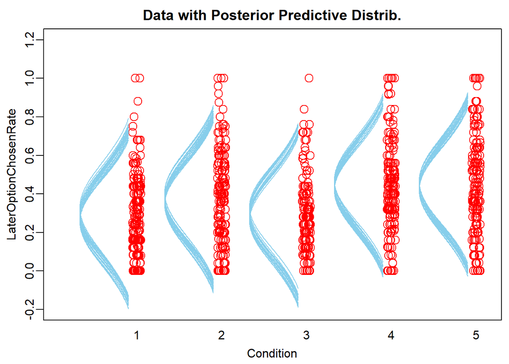

```r
## Moustache Plot
plotMoustache(chains, data.frame(DT), yName = "LaterOptionChosenRate", xName = "Condition")
```

#### Contrasts

Idea: construct the desired contrasts by taking the difference between conditions and visualize the sample posterior distributions.

Contrasts table

|  | Condition 1 | Condition 2 | Condition 3 | Condition 4 | Condition 5 |
| --- | --- | --- | --- | --- | --- |
| Standard MEL vs. Absolute Gains | -1 | 0 | 1 | 0 | 0 |
| Standard MEL vs. Relative Gains | 0 | -1 | 1 | 0 | 0 |
| Standard MEL vs. Absolute Losses | 0 | 0 | 1 | -1 | 0 |
| Standard MEL vs. Relative Losses | 0 | 0 | 1 | 0 | -1 |
| Absolute Condition vs. Relative Condition | 1/2 | -1/2 | 0 | 1/2 | -1/2 |

Standard MEL vs. Absolute Gains:

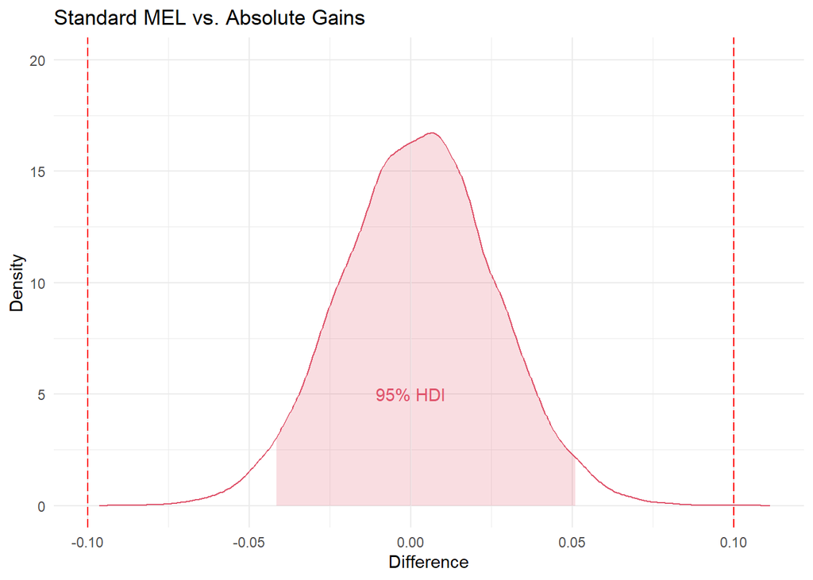

```r
## Region of practical equivalence
ROPE <- c(-0.1, 0.1)

dif <- b.samples$Condition3 - b.samples$Condition1
d.density <- with(density(dif), data.frame(x, y))
ggplot(data=d.density, mapping=aes(x=x, y=y)) +
  geom_area(aes(x=ifelse(x>hdi(dif)[1] & x<hdi(dif)[2], x, 0), y=y), fill=2, alpha=0.2) +
  geom_line(color=2) + ylim(0, 20) + geom_vline(xintercept=ROPE, linetype="longdash", color="red") +
  geom_text(aes(x=0, y=5, label="95% HDI"), color=2, check_overlap=TRUE) +
  labs(title="Standard MEL vs. Absolute Gains", x="Difference", y="Density") + theme_minimal()
```

Standard MEL vs. Relative Gains:

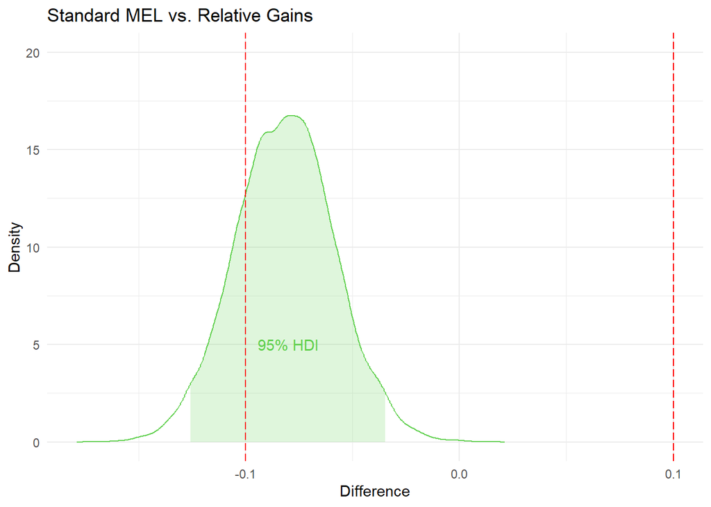

```r
dif <- b.samples$Condition3 - b.samples$Condition2
d.density <- with(density(dif), data.frame(x, y))
ggplot(data=d.density, mapping=aes(x=x, y=y)) +
  geom_area(aes(x=ifelse(x>hdi(dif)[1] & x<hdi(dif)[2], x, NA), y=y), fill=3, alpha=0.2) +
  geom_line(color=3) + ylim(0, 20) + geom_vline(xintercept=ROPE, linetype="longdash", color="red") +
  geom_text(aes(x=-0.08, y=5, label="95% HDI"), color=3, check_overlap=TRUE) +
  labs(title="Standard MEL vs. Relative Gains", x="Difference", y="Density") + theme_minimal()
```

Standard MEL vs. Absolute Losses:

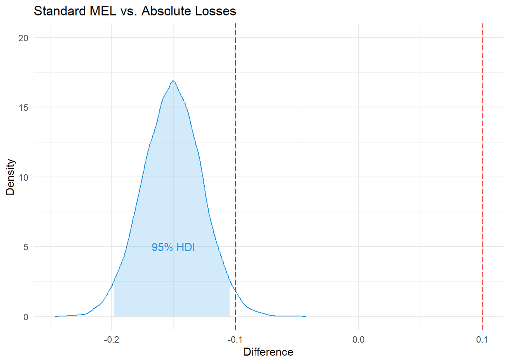

```r
dif <- b.samples$Condition3 - b.samples$Condition4
d.density <- with(density(dif), data.frame(x, y))
ggplot(data=d.density, mapping=aes(x=x, y=y)) +
  geom_area(aes(x=ifelse(x>hdi(dif)[1] & x<hdi(dif)[2], x, NA), y=y), fill=4, alpha=0.2) +
  geom_line(color=4) + ylim(0, 20) + geom_vline(xintercept=ROPE, linetype="longdash", color="red") +
  geom_text(aes(x=-0.15, y=5, label="95% HDI"), color=4, check_overlap=TRUE) +
  labs(title="Standard MEL vs. Absolute Losses", x="Difference", y="Density") + theme_minimal()
```

Standard MEL vs. Relative Losses:

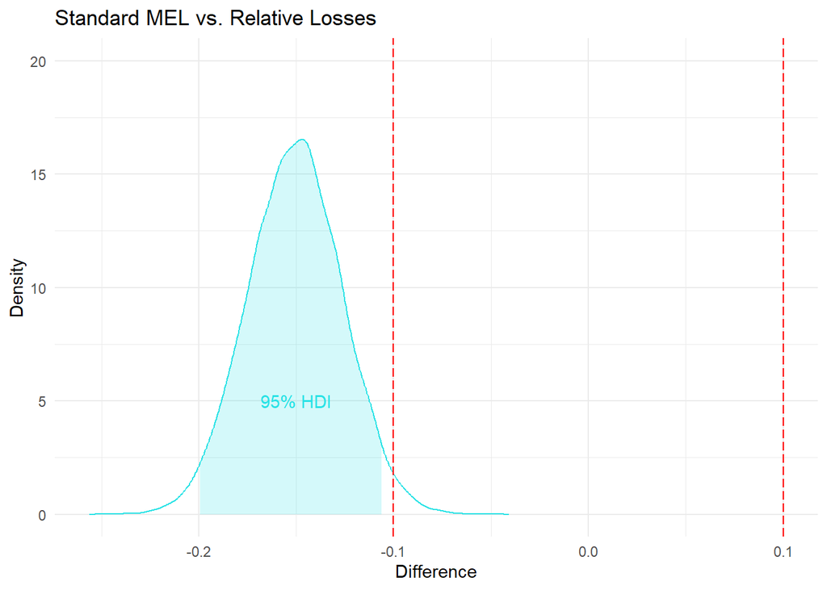

```r
dif <- b.samples$Condition3 - b.samples$Condition5
d.density <- with(density(dif), data.frame(x, y))
ggplot(data=d.density, mapping=aes(x=x, y=y)) +
  geom_area(aes(x=ifelse(x>hdi(dif)[1] & x<hdi(dif)[2], x, NA), y=y), fill=5, alpha=0.2) +
  geom_line(color=5) + ylim(0, 20) + geom_vline(xintercept=ROPE, linetype="longdash", color="red") +
  geom_text(aes(x=-0.15, y=5, label="95% HDI"), color=5, check_overlap=TRUE) +
  labs(title="Standard MEL vs. Relative Losses", x="Difference", y="Density") + theme_minimal()
```

Absolute Condition vs. Relative Condition:

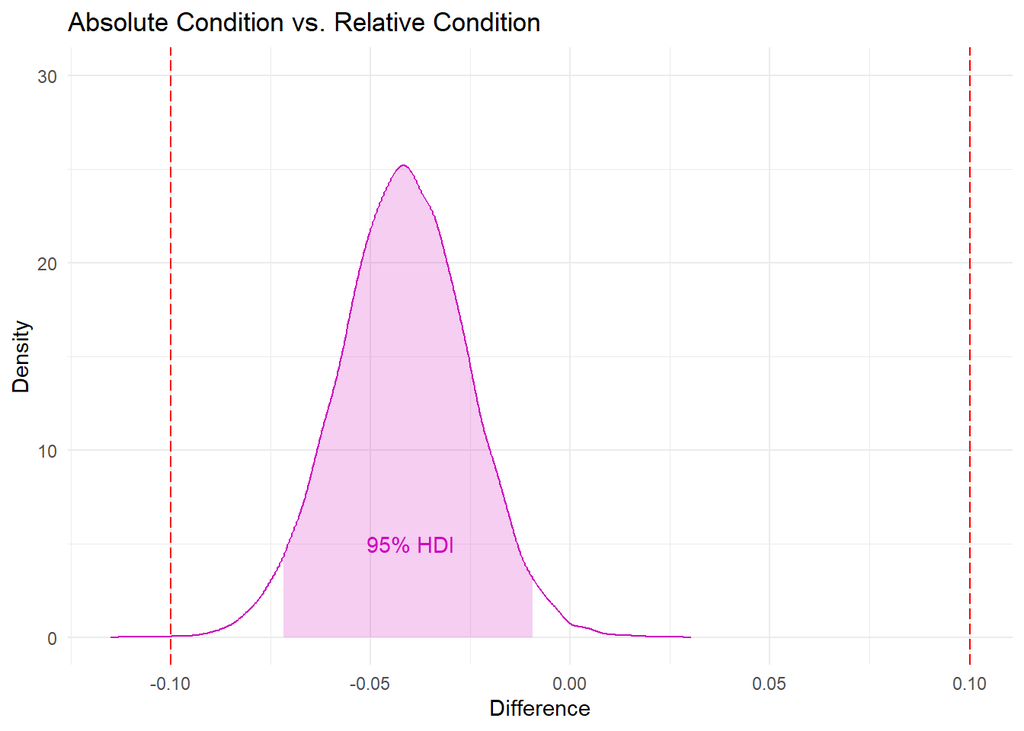

```r
dif <- (b.samples$Condition1 + b.samples$Condition4)/2 - (b.samples$Condition2 + b.samples$Condition5)/2
d.density <- with(density(dif), data.frame(x, y))
ggplot(data=d.density, mapping=aes(x=x, y=y)) +
  geom_area(aes(x=ifelse(x>hdi(dif)[1] & x<hdi(dif)[2], x, NA), y=y), fill=6, alpha=0.2) +
  geom_line(color=6) + ylim(0, 30) + geom_vline(xintercept=ROPE, linetype="longdash", color="red") +
  geom_text(aes(x=-0.04, y=5, label="95% HDI"), color=6, check_overlap=TRUE) +
  labs(title="Absolute Condition vs. Relative Condition", x="Difference", y="Density") + theme_minimal()
```